## iterative Random Forests (iRF)

The R package `iRF` implements iterative Random Forests, a method for iteratively growing ensemble of weighted decision trees, and detecting high-order feature interactions by analyzing feature usage on decision paths. It uses source codes from the R package `randomForest` by Andy Liaw and Matthew Weiner, the original Fortran codes by Leo Breiman and Adele Cutler, and source codes from the R package `FSInteract` by Hyun Jik Kim and Rajen D. Shah.

`iRF` can be loaded using the `library` command:

```r
library(iRF)
```

`iRF` adds two new features to Breiman’s original Random Forest workflow:

## A. Weighted random forest

Unlike Breiman’s original random forest, which uses uniform random sampling to select variables during each node split, the ‘randomForest’ function in ‘iRF’ allows non-uniform sampling using a given vector of nonnegative weights (e.g., feature importances from a previous model fit). In particular, given a vector of weights $\mathbf{w} = (w_1, \ldots, w_p)$, the `mtry` variables are selected so that $P(\text{variable }j \text{ is selected}) = w_j/\sum_{j=1}^p w_j$, for $j = 1, \ldots, p$.

Based on this weighting scheme, we can iteratively grow weighted random forests, where Gini importances from the previous random forest fit are used as weights in the current iteration.

```r
# set seed for random number generation
set.seed(47)
```

### Binary Classification:

We simulate some data for a binary classification exercise. Out of $250$ features, only three $\{1, 2, 3\}$ are important.

```r
  # simulate data for classification
  n <- 500
  p <- 250
  X <- matrix(rnorm(n * p), nrow=n)

  Y <- as.numeric(X[,1] > 0 & X[,2] > 0 & X[,3] > 0)
  Y <- as.factor(Y)

  train.id <- 1:(n / 2)
  test.id <- setdiff(1:n, train.id)
```

Next, we iteratively grow weighted random forests and use feature importances from last iteration as weights.

```r
sel.prob <- rep(1/p, p)

# iteratively grow RF, use Gini importance of features as weights
rf <- list()
for (iter in 1:4){
  rf[[iter]] <- randomForest(x=X[train.id,], y=Y[train.id],
                             xtest=X[test.id,], ytest=Y[test.id],
                             mtry.select.prob=sel.prob)

  # update selection probabilities for next iteration
  sel.prob <- rf[[iter]]$importance
}
```

### ROC curve

We can measure performance of different iterations of RF on the test set:

```r
library(AUC)
plot(0:1, 0:1, type='l', lty = 2, xlab = 'FPR', ylab = 'TPR', main='ROC Curve')
for (iter in 1:4){
  # performance on test set
  cat(paste('iter = ', iter, ':: '))
  roc.info <- roc(rf[[iter]]$test$votes[,2], Y[test.id])
  lines(roc.info$fpr, roc.info$tpr, type='l', col=iter, lwd=2)
  cat(paste('AUROC: ', round(100*auc(roc.info), 2), '%\n', sep=''))
}
```

```
## iter =  1 :: AUROC: 91.34%
## iter =  2 :: AUROC: 99.3%
## iter =  3 :: AUROC: 99.7%
## iter =  4 :: AUROC: 99.7%
```

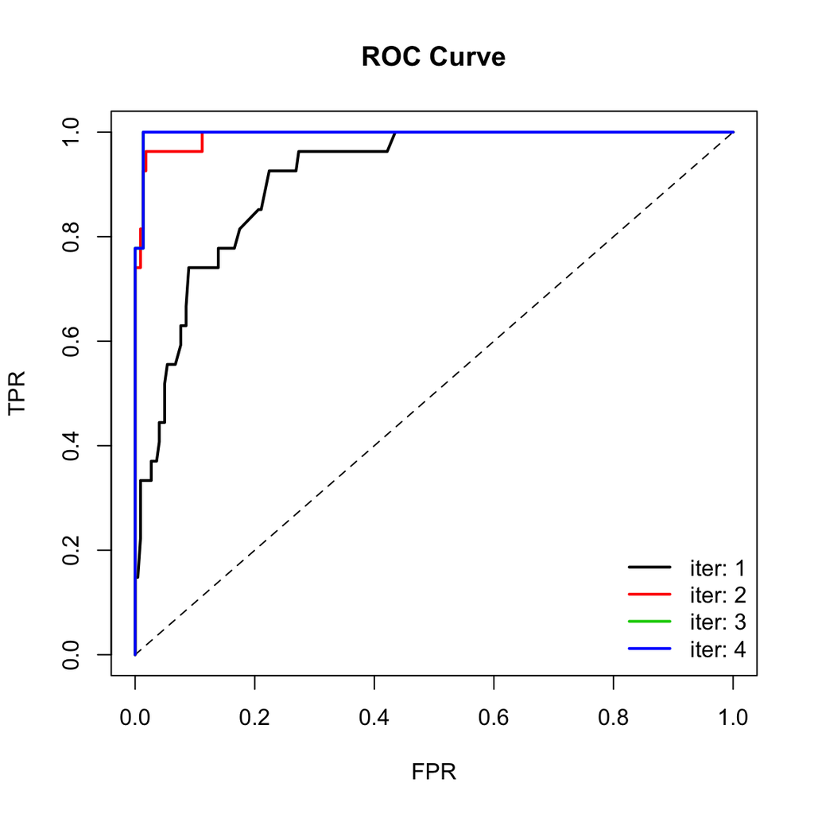

```r
legend('bottomright', legend=paste('iter:', 1:iter), col=1:iter, lwd=2, bty='n')
```

### Variable Importance

The outputs of `iRF::randomForest` are objects of class `randomForest` and can be used with other functions in the R package `randomForest` directly, e.g., to visualize variable importance measures:

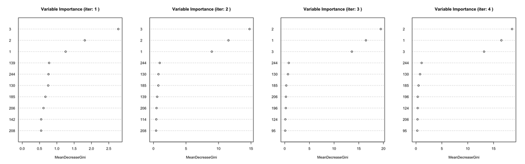

```r
par(mfrow=c(1,4))
for (iter in 1:4)
  varImpPlot(rf[[iter]], n.var=10,
             main=paste('Variable Importance (iter:', iter, ')')
             )
```

### Regression

For regression, the usage is similar:

```r
# change to a continuous response
y <- as.numeric(Y) + rnorm(n, sd=0.25)

# iteratively grow RF, use Gini importance of features as weights
rf <- list()
sel.prob <- rep(1/p, p)
for (iter in 1:4){
  cat(paste('iter = ', iter, ':: '))
  rf[[iter]] <- randomForest(x=X[train.id,], y=y[train.id],
                             xtest=X[test.id,], ytest=y[test.id],
                             mtry.select.prob=sel.prob)

  # update selection probabilities for next iteration
  sel.prob <- rf[[iter]]$importance/sum(rf[[iter]]$importance)

  # performance on test set
  ytest <- y[test.id]
  test.error = 1 - mean((rf[[iter]]$test$predicted - ytest) ^ 2) / var(ytest)
  cat(paste('% var explained: ', round(100 * test.error, 2), '%\n', sep=''))
}
```

```
## iter =  1 :: % var explained: 20.32%
## iter =  2 :: % var explained: 44.3%
## iter =  3 :: % var explained: 40.9%
## iter =  4 :: % var explained: 43.39%
```

### Parallel implementation

```r
# set up cores for parallel implementation
library(doMC)
registerDoMC()
n.cores <- detectCores()
options(cores=n.cores)
n.tree.per.core <- 30

rfpar <- foreach(n.tree=rep(n.tree.per.core, n.cores),
                 .combine=combine, .multicombine=TRUE) %dopar% {
   randomForest(x=X[train.id,], y=Y[train.id], ntree=n.tree)
}
```

## B. Detect high-order feature interactions in a stable fashion

`iRF` detects high-order interaction among features by analyzing feature usage on the decision paths of a random forest. In particular, given a (weighted) random forest fit, `iRF` (i) passes the training data through the fitted forest and records the features used on the associated decision paths; (ii) Applies a weighted version of the random intersection tree (RIT) algorithm proposed by [Shah and Meinshausen (2014)](http://jmlr.org/papers/v15/shah14a.html) to find high-order feature combinations prevalent on the decision paths, where weights are determined by user specified features; (iii) performs the above two steps on many bootstrap replicates of the training set to assess stability of the features and their interactions.

### Feature usage on decision paths of large leaf nodes

Consider a classification example as before. We iteratively grow weighted random forests, but save the forest components for further processing.

```r
sel.prob <- rep(1/p, p)

# iteratively grow RF, use Gini importance of features as weights
rf <- list()
for (iter in 1:4){
  rf[[iter]] <- randomForest(x=X[train.id,], y=Y[train.id],
                             xtest=X[test.id,], ytest=Y[test.id],
                             mtry.select.prob=sel.prob,
                             keep.forest=TRUE)

  # update selection probabilities for next iteration
  sel.prob <- rf[[iter]]$importance / sum(rf[[iter]]$importance)
}
```

To read feature usage on nodes, use the function `readForest`. This function can be run in parallel with the argument `n.core`, provided `doMC` has been set up for parallel processing.

```r
rforest <- readForest(rand.forest=rf[[3]], x=X[train.id,])
```

The `tree.info` data frame provides meta data for each leaf node.

```r
head(rforest$tree.info, n=10)
```

```
##     prediction node.idx parent tree size.node
##  1:          1        5      2    1         1
##  2:          0        6      3    1        20
##  3:          0       10      7    1         6
##  4:          1       11      7    1        13
##  5:          0       12      8    1         2
##  6:          1       13      8    1         5
##  7:          0       14      9    1       166
##  8:          1       17     15    1         5
##  9:          0       18     16    1        30
## 10:          1       19     16    1         2
```

The `readForest` function optionally computes a sparse matrix `node.feature` that encodes the splitting features and direction of inequality along the decision path of each leaf node. This encoding can be represented as a binary vector of length $2p$`, where an entry $j\in\{1\dots p\}$ indicates that a decision path contains the left child of a node that splits on feature $j$ and an entry $j\in\{p+1\dots 2p\}$ indicates that a decision path contains the right child of a node that splits on feature $j-p$.

```r
rforest$node.feature[1:10, c(1:5, p + 1:5)]
```

```
## 10 x 10 sparse Matrix of class "dgCMatrix"
##
##  [1,] .       .           0.7885846 . . .       .           .         . .
##  [2,] 0.22417 .           .         . . .       .           0.7885846 . .
##  [3,] .       0.008292266 .         . . 0.22417 .           0.7885846 . .
##  [4,] .       .           .         . . 0.22417 0.008292266 0.7885846 . .
##  [5,] .       .           0.7885846 . . .       .           .         . .
##  [6,] .       .           0.7885846 . . .       .           .         . .
##  [7,] .       .           0.2765838 . . .       .           .         . .
##  [8,] .       .           0.7885846 . . .       1.047271616 .         . .
##  [9,] .       1.047271616 0.7885846 . . .       .           .         . .
## [10,] .       1.047271616 0.7885846 . . .       .           .         . .
```

### Finding feature interactions using random intersection trees (RIT)

To find prevalent sets of features and their high-order combinations used to define these nodes, use the random intersection trees (RIT) function. The following command runs RIT on all class 1 nodes, sampling each leaf node with probability proportional to the number of observations in each leaf node:

```r
class1.nodes <- rforest$tree.info$prediction == 1
wt <- rforest$tree.info$size.node[class1.nodes]
RIT(rforest$node.feature[class1.nodes,], weights=wt,
    depth=5, branch=2, n_trees=100)
```

```
##   Interaction Prevalence
## 1     252 253 0.45303867
## 2     251 253 0.41666667
## 3     251 252 0.40306122
## 4 251 252 253 0.40000000
## 5       3 185 0.05970149
## 6      69 494 0.01421189
```

### Selecting Stable interactions

The function `iRF` combines all the above steps and uses bootstrap aggregation to assess stability of the selected interactions. Setting `select.iter = TRUE` chooses the optimal iteration number by maximizing prediction accuracy on out of bag samples and searches for interactions in the corresponding random forest.

```r
fit <- iRF(x=X[train.id,],
           y=Y[train.id],
           n.iter=5,
           n.core=n.cores,
           n.bootstrap=10
        )
```

```
## [1] "iteration =  1"
## [1] "iteration =  2"
## [1] "iteration =  3"
## [1] "iteration =  4"
## [1] "iteration =  5"
## finding interactions...
## evaluating interactions...
```

1. `rf.list`: a `randomForest` object.
2. `iter.select`: The selected iteration.
3. `interaction`: a data table of interactions and associated importance metrics. For a more detailed description of these importance metrics, see our paper: https://arxiv.org/abs/1810.07287.
   - `int` indicates the interaction, with $+$ and $-$ describing whether the interaction is characterized by high or low levels of the feature. For instance, the interaction `X1+_X2+_X3+` corresponds to decision rules of the form $1(x_1 > & x_2 > & x_3 > ).
   - `prevalence` indicates the proportion of class-1 leaf nodes that contain the interaction, weighted y the size of the leaf nodes.
   - `precision` indicates the proportion of class-1 observations that fall in leaf nodes that contain the innteraction.
   - `cpe` indicates the class prevalence enrichment, which is defined as the difference in prevalence betweenn class-0 and class-1 leaf nodes. `sta.cpe` indicates the proportion of times this value is greater than 0 across bootstrap replicates.
   - `fsd` indicates the feature selection dependence, which is defined as the difference between the prevalence of an interaction and its expected prevalence if interacting features were selected independently of one another. `sta.fsd` indicates the proportion of times this value is greater than 0 across bootstrap replicates.
   - `mip` indicates the mean increase in precision, which is defined as the difference etween the precision of an interaction and the average precision of lower order subsets. `sta.mip` indicates the proportion of times this value is greater than 0 across bootstrap replicates.
   - `stability` indicates the proportion of times the interaction was recovered by RIT across bootstrap replicates.

```r
head(fit$interaction)
```

```
##            int  prevalence precision          cpe sta.cpe          fsd
## 1:     X2+_X3+ 0.684393466 0.7749206  0.670889816       1  0.166939137
## 2:     X1+_X3+ 0.267615675 0.9149261  0.266431665       1  0.066102086
## 3:     X1+_X2+ 0.263542927 0.9561326  0.263520032       1  0.066938513
## 4: X1+_X2+_X3+ 0.260956969 0.9586200  0.260956969       1  0.117628688
## 5:   X244+_X3+ 0.002088731 0.4773968  0.001935259       1 -0.008999658
## 6:   X206+_X3- 0.022772245 0.1139316 -0.017229811       0  0.016294375
##    sta.fsd          mip sta.mip stability
## 1:       1  0.081503095     1.0       1.0
## 2:       1  0.058241862     1.0       1.0
## 3:       1  0.099448358     1.0       0.6
## 4:       1  0.002487407     0.7       0.9
## 5:       0  0.125278134     0.7       0.0
## 6:       1 -0.015949886     0.0       0.1
```

4. `weights` feature weights used to fit the selected random forest.

The selected interactions can be visualized using simple R functions like `dotchart`:

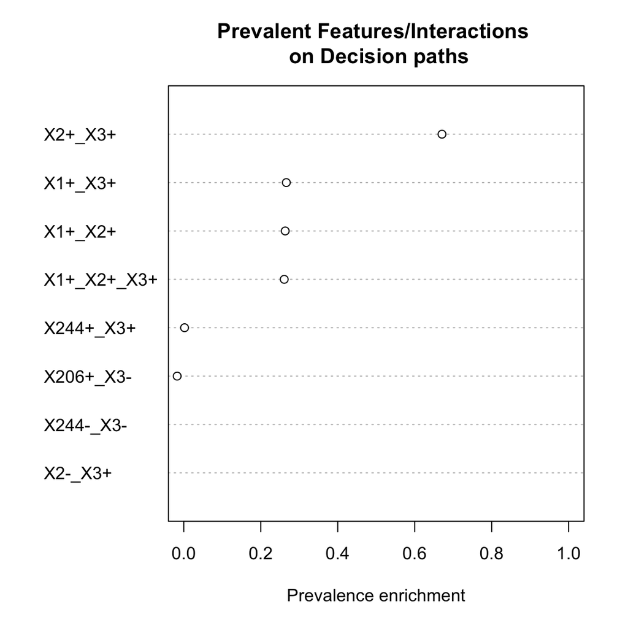

```r
toplot <- fit$interaction$cpe
names(toplot) <- fit$interaction$int

dotchart(rev(toplot[1:min(20, length(toplot))]),
         xlab='Prevalence enrichment', xlim=c(0, 1),
         main='Prevalent Features/Interactions \n on Decision paths')
```

### Visualizing interactions

Interactions can be visualized using response surfaces, which depict the expected response as a function of interacting features. We use the output of `readForest` to generate response surfaces as follows

```r
library(rgl)

rforest <- readForest(fit$rf.list, x=X[train.id,])
plotInt(x=X[test.id,], y=Y[test.id], int='X1+_X2+_X3+',
        read.forest=rforest,
        xlab='X1', ylab='X2')
rglwidget()
```

[interactive chart not shown]

The response surface to the left is plotted for observations whose X3 value is below the median random forest threshold, while the response surface to the right is plotted for observations whose X3 value is above the median random forest threshold. `plotInt` is supported for up to order-4 interactions.